# Humanities enrolments in NZ, 2008-2017

Kate Newton

9 October 2018

## Load libraries and data

```r
library(readr)
library(readxl)
library(tidyr)
library(dplyr)
library(ggplot2)
library(RColorBrewer)
```

The data for this story came from the New Zealand Education Ministry’s statistics repository, [educationcounts.co.nz](https://www.educationcounts.govt.nz/statistics/tertiary-education/participation)

```r
majors <- read_excel("Provider-based-enrolments-predominant-field-of-study-2017-final.xlsx", sheet=8)
```

## Tidying data

```r
# Select only columns for students at bachelor degree level and higher

majors <- majors %>%
  select(`Students by field of study (broad, narrow and detailed) and qualification type/level 2008-2017`,
         X__1, X__2, X__173:X__182, X__233:X__242, X__263:X__272, X__293:X__302)

# Remove unneeded headers

majors <- majors[-c(1:4),]
majors <- majors[-c(453:465),]

# Tidy up variable names

majors[1:39, 1] <- "Natural and physical sciences"
majors[40:61, 1] <- "Information technology"
majors[62:143, 1] <- "Engineering"
majors[144:165, 1] <- "Architecture and building"
majors[166:193, 1] <- "Agriculture and environmental studies"
majors[194:255, 1] <- "Health"
majors[256:276, 1] <- "Education"
majors[277:318, 1] <- "Management and commerce"
majors[319:389, 1] <- "Society and culture"
majors[390:419, 1] <- "Creative arts"
majors[420:432, 1] <- "Food, hospitality and personal services"
majors[433:452, 1] <- "Mixed field programmes"

# Remove totals

majors <- majors[-c(1, 40, 62, 144, 166, 194, 256, 277, 319, 390, 420, 433),]

# Don't need narrow field column

majors <- majors[-2]

# And now remove sub-totals

majors <- majors[-c(1, 5, 8, 12, 21, 32, 39, 51, 57, 60, 70, 78, 88, 99, 109,
                    113, 124, 130, 135, 141, 147, 162, 172, 175, 178, 182, 186, 189,
                    200, 205, 207, 212, 216, 220, 228, 230, 239, 244, 250, 265,
                    268, 270, 273, 288, 295, 297, 301, 306, 311, 314, 325, 336,
                    339, 348, 353, 356, 365, 368, 371, 375, 381, 387, 395, 401,
                    408, 410, 418, 422, 427, 432, 437, 439, 440),]

# Rename columns

majors <- majors %>%
  rename(Field.of.study=`Students by field of study (broad, narrow and detailed) and qualification type/level 2008-2017`,
         Major=X__2,
         `2008.bachelor`=X__173, `2009.bachelor`=X__174, `2010.bachelor`=X__175, `2011.bachelor`=X__176,
         `2012.bachelor`=X__177, `2013.bachelor`=X__178, `2014.bachelor`=X__179, `2015.bachelor`=X__180,
         `2016.bachelor`=X__181, `2017.bachelor`=X__182,
         `2008.hon_pgdip`=X__233, `2009.hon_pgdip`=X__234, `2010.hon_pgdip`=X__235, `2011.hon_pgdip`=X__236,
         `2012.hon_pgdip`=X__237, `2013.hon_pgdip`=X__238, `2014.hon_pgdip`=X__239, `2015.hon_pgdip`=X__240,
         `2016.hon_pgdip`=X__241, `2017.hon_pgdip`=X__242,
         `2008.masters`=X__263, `2009.masters`=X__264, `2010.masters`=X__265, `2011.masters`=X__266,
         `2012.masters`=X__267, `2013.masters`=X__268, `2014.masters`=X__269, `2015.masters`=X__270,
         `2016.masters`=X__271, `2017.masters`=X__272,
         `2008.phd`=X__293, `2009.phd`=X__294, `2010.phd`=X__295, `2011.phd`=X__296, `2012.phd`=X__297,
         `2013.phd`=X__298, `2014.phd`=X__299, `2015.phd`=X__300, `2016.phd`=X__301, `2017.phd`=X__302)
```

## Create tall data

The data is currently separated out both by year and by level of study, which means it can’t immediately be turned into useful tall data. To get round this, I created a dataframe for each year, standardised the column names and then bound them back into a single dataframe

```r
# Separate dataframes

majors_2008 <- majors[,c(1, 2, 3, 13, 23, 33)]
majors_2009 <- majors[,c(1, 2, 4, 14, 24, 34)]
majors_2010 <- majors[,c(1, 2, 5, 15, 25, 35)]
majors_2011 <- majors[,c(1, 2, 6, 16, 26, 36)]
majors_2012 <- majors[,c(1, 2, 7, 17, 27, 37)]
majors_2013 <- majors[,c(1, 2, 8, 18, 28, 38)]
majors_2014 <- majors[,c(1, 2, 9, 19, 29, 39)]
majors_2015 <- majors[,c(1, 2, 10, 20, 30, 40)]
majors_2016 <- majors[,c(1, 2, 11, 21, 31, 41)]
majors_2017 <- majors[,c(1, 2, 12, 22, 32, 42)]

# Standardise column names so dataframes will bind

majors_2008 <- majors_2008 %>%
  rename(Bachelor=`2008.bachelor`,
         Hons.PGDip=`2008.hon_pgdip`,
         Masters=`2008.masters`,
         PhD=`2008.phd`) %>%
  gather("Level", "2008 students", 3:6)

majors_2009 <- majors_2009 %>%
  rename(Bachelor=`2009.bachelor`,
         Hons.PGDip=`2009.hon_pgdip`,
         Masters=`2009.masters`,
         PhD=`2009.phd`) %>%
  gather("Level", "2009 students", 3:6)

majors_2010 <- majors_2010 %>%
  rename(Bachelor=`2010.bachelor`,
         Hons.PGDip=`2010.hon_pgdip`,
         Masters=`2010.masters`,
         PhD=`2010.phd`) %>%
  gather("Level", "2010 students", 3:6)

majors_2011 <- majors_2011 %>%
  rename(Bachelor=`2011.bachelor`,
         Hons.PGDip=`2011.hon_pgdip`,
         Masters=`2011.masters`,
         PhD=`2011.phd`) %>%
  gather("Level", "2011 students", 3:6)

majors_2012 <- majors_2012 %>%
  rename(Bachelor=`2012.bachelor`,
         Hons.PGDip=`2012.hon_pgdip`,
         Masters=`2012.masters`,
         PhD=`2012.phd`) %>%
  gather("Level", "2012 students", 3:6)

majors_2013 <- majors_2013 %>%
  rename(Bachelor=`2013.bachelor`,
         Hons.PGDip=`2013.hon_pgdip`,
         Masters=`2013.masters`,
         PhD=`2013.phd`) %>%
  gather("Level", "2013 students", 3:6)

majors_2014 <- majors_2014 %>%
  rename(Bachelor=`2014.bachelor`,
         Hons.PGDip=`2014.hon_pgdip`,
         Masters=`2014.masters`,
         PhD=`2014.phd`) %>%
  gather("Level", "2014 students", 3:6)

majors_2015 <- majors_2015 %>%
  rename(Bachelor=`2015.bachelor`,
         Hons.PGDip=`2015.hon_pgdip`,
         Masters=`2015.masters`,
         PhD=`2015.phd`) %>%
  gather("Level", "2015 students", 3:6)

majors_2016 <- majors_2016 %>%
  rename(Bachelor=`2016.bachelor`,
         Hons.PGDip=`2016.hon_pgdip`,
         Masters=`2016.masters`,
         PhD=`2016.phd`) %>%
  gather("Level", "2016 students", 3:6)

majors_2017 <- majors_2017 %>%
  rename(Bachelor=`2017.bachelor`,
         Hons.PGDip=`2017.hon_pgdip`,
         Masters=`2017.masters`,
         PhD=`2017.phd`) %>%
  gather("Level", "2017 students", 3:6)

# New tall dataframe

majors_tall <- cbind(majors_2008, majors_2009$`2009 students`, majors_2010$`2010 students`, majors_2011$`2011 students`, majors_2012$`2012 students`, majors_2013$`2013 students`, majors_2014$`2014 students`, majors_2015$`2015 students`, majors_2016$`2016 students`, majors_2017$`2017 students`)

# Rename columns and convert one random character column to numeric

majors_tall <- majors_tall %>%
  rename(`2008`=4,
         `2009`=5,
         `2010`=6,
         `2011`=7,
         `2012`=8,
         `2013`=9,
         `2014`=10,
         `2015`=11,
         `2016`=12,
         `2017`=13)

majors_tall$`2008` <- as.numeric(majors_tall$`2008`)

# Optional: Clean up environment - these will not be needed again

#rm(majors_2008)
#rm(majors_2009)
#rm(majors_2010)
#rm(majors_2011)
#rm(majors_2012)
#rm(majors_2013)
#rm(majors_2014)
#rm(majors_2015)
#rm(majors_2016)
#rm(majors_2017)
```

## Create dataframes for visualisation

To visualise data, I go one step further and combine the year columns to create tidy data that can be used to calculate/visualise data for all students. I repeated the process for the humanities, first filtering majors_tall to only include majors (‘detailed field of study’ on the original Excel sheet) that RNZ deemed to be unambiguously ‘humanities’ majors - all of them within the ‘Society and Culture’ field of study category.

The exclusions included:

- Creative Arts majors, which, while often closely related to the humanities, tended to be either more vocational (eg journalism) or normally studied as a degree other than a BA (eg music).
- Economics and econometrics, which can be studied as arts, science or commerce majors, but anecdotally, from talking to academics and students, is predominantly taken as a commerce major.
- Many ‘caring’ subjects that were strongly linked to a particular vocation
- Law - included in the ‘Society and Culture’ field but has its own degree and a specific vocation.
- English for Speakers of Other Languages
- Sports-related subjects
- A small number of subjects that were tied to vocational qualifications (eg Librarianship and Information Management)

The filtered data kept four variables where the student’s predominant area of study fell within a broad humanities category but was deemed “nec, mixed or nfd” - mixed, not elsewhere classified, or not further defined.

```r
majors_taller <- majors_tall %>%
  gather("Year", "Students", 4:13)

humanities_tall <- majors_tall %>%
  filter(Field.of.study=="Society and culture") %>%
  select(-Field.of.study) %>%
  filter(Major %in% c("Political Science", "Policy Studies", "Sociology", "Anthropology", "History", "Art History", "Archaeology", "Classics", "Human Geography", "Women's Studies", "Studies in Human Society nec, mixed or nfd", "Behavioural Science nec, mixed or nfd", "Curatorial Studies", "English Language", "Criminology", "Te Reo Maori", "Foreign Languages", "Linguistics", "Literature", "Language and Literature nec, mixed or nfd", "Philosophy", "Religious Studies", "Community, Whanau, Family and Consumer Studies", "Cultural Studies", "Society and Culture nec, mixed or nfd"))

humanities_taller <- humanities_tall %>%
  gather("Year", "Students", 3:12)
```

# Visualise change in humanities numbers

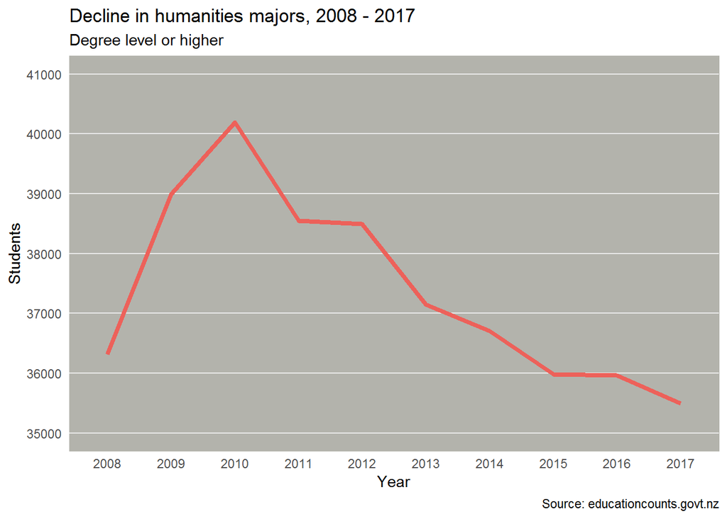

```r
# Summarise by year

humanities_drop <- humanities_taller %>%
  group_by(Year) %>%
  summarise(Students = sum(Students))

# Line graph of overall change in humanities student numbers year by year

ggplot(humanities_drop, aes(x=Year, y=Students, group=1)) +
  geom_line(color="#ED615A", size=1.5) +
  theme_minimal() +
  labs(title="Decline in humanities majors, 2008 - 2017", subtitle="Degree level or higher", caption="Source: educationcounts.govt.nz") +
  scale_y_continuous(breaks=seq(35000,41000,1000), limits=c(35000,41000)) +
  theme(panel.grid.minor = element_blank(),
        panel.grid.major.x = element_blank(),
        panel.background = element_rect(fill="#B3B3AC", colour = "#B3B3AC"))
```

# Visualise biggest changes in major

There were changes to student enrolments in almost every subject, but to show those with the biggest impact, we’ve limited this graphic to the 10 largest +/- changes, by raw student numbers. It’s possible to visualise this by the largest percentage changes, but some of those changes happened within subjects with very low numbers of students. However, I’ve left in the code to create this column.

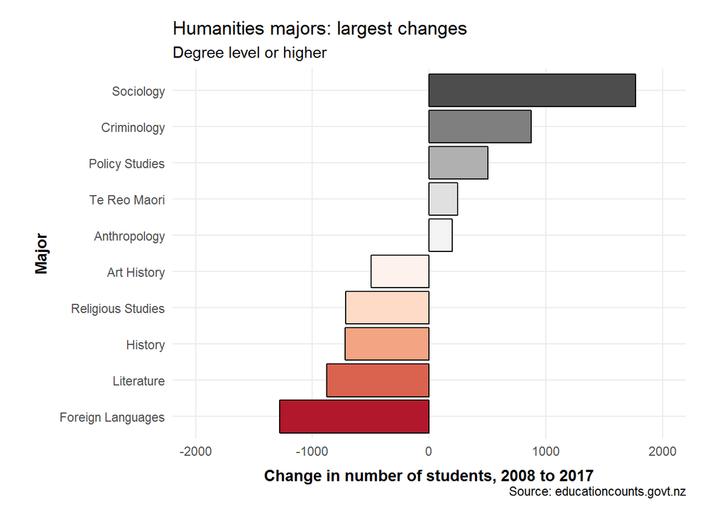

```r
# Merge the different levels of study, filter out the non-specific variables and arrange from biggest gain to biggest loss

all_levels <- humanities_taller %>%
  group_by(Major, Year) %>%
  summarise(Students = sum(Students)) %>%
  filter(Year %in% c("2008", "2017")) %>%
  spread("Year", "Students") %>%
  mutate(Gap=`2017`-`2008`) %>%
  mutate(percent_change=Gap/`2008`*100) %>%
  filter(!(Major %in% c("Studies in Human Society nec, mixed or nfd", "Behavioural Science nec, mixed or nfd", "Language and Literature nec, mixed or nfd", "Society and Culture nec, mixed or nfd"))) %>%
  arrange(Gap)

all_levels$Major <- factor(all_levels$Major, levels=unique(all_levels$Major))

#Top Ten +/- change

all_levels_ten <- all_levels %>%
  filter(Major %in% c("Sociology", "Criminology", "Policy Studies", "Te Reo Maori",
                      "Anthropology", "Art History", "Religious Studies", "History",
                      "Literature", "Foreign Languages"))

colourCount = length(unique(all_levels_ten$Major))

ggplot(all_levels_ten, aes(Major, Gap, fill = Major)) +
  geom_bar(stat = 'identity', position = 'identity', color="black") +
  coord_flip() +
  guides(fill = "none") +
  labs(y="Change in number of students, 2008 to 2017", title="Humanities majors: largest changes", caption="Source: educationcounts.govt.nz", subtitle="Degree level or higher") +
  scale_fill_manual(values = colorRampPalette(brewer.pal(7, "RdGy"))(colourCount)) +
  scale_y_continuous(breaks=seq(-2000, 2000, 1000), limits=c(-2000,2000)) +
  theme_minimal() +
  theme(panel.grid.minor = element_blank(),
        plot.margin = unit(c(0.5,1,0.5,1), "cm"),
        axis.title.y = element_text(vjust=3, face="bold"),
        axis.title.x = element_text(vjust=-1, face="bold"))
```

# Humanities as a proportion of all students

```r
# Create summary of total student numbers that can be used to calculate percentages

total_uni_students <- majors_taller %>%
  group_by(Year) %>%
  summarise(Students = sum(Students))
```

```r
# Calculate humanities students as a proportion

proportion <- left_join(humanities_drop, total_uni_students, by="Year") %>%
  rename("humanities_students"="Students.x",
         "all_students"="Students.y") %>%
  mutate("percent"=(humanities_students/all_students*100))

# Next calculate society and culture students (the wider group humanities falls under) as a proportion

fields_proportion <- majors_taller %>%
  filter(Field.of.study=="Society and culture") %>%
  group_by(Year) %>%
  summarise(society.and.culture.students=sum(Students))

fields_proportion <- left_join(fields_proportion, total_uni_students, by="Year") %>%
  mutate("percent"=society.and.culture.students/Students*100)
```

```r
# Combine the two

all_proportion <- left_join(fields_proportion, proportion, by="Year") %>%
  select(-(c(Students, percent.x, percent.y))) %>%
  rename(`Total students`=all_students,
         `Society and Culture students`=society.and.culture.students,
         `Humanities students`=humanities_students) %>%
  mutate(`Humanities students`=`Humanities students`/`Total students`*100,
         `Society and Culture students`=`Society and Culture students`/`Total students`*100,
         `Total students`=`Total students`/`Total students`*100) %>%
  mutate(`Total students`=`Total students`-`Society and Culture students`) %>%
  mutate(`Society and Culture students`=`Society and Culture students`-`Humanities students`)%>%
  gather("Type", "Count", 2:4) %>%
  rename(Percent=Count)

all_proportion$Year <- as.numeric(all_proportion$Year)
all_proportion$Type <- factor(all_proportion$Type, levels=unique(all_proportion$Type))
```

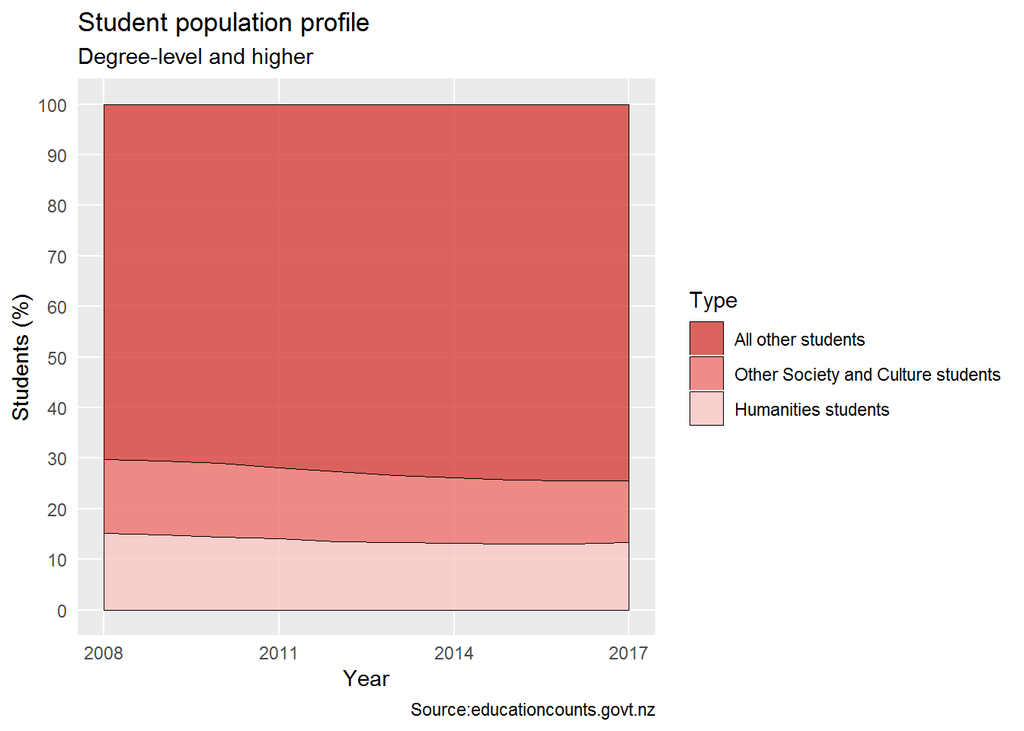

```r
# Visualise as stacked area chart

ggplot(all_proportion, aes(x=Year, y=Percent, fill=Type)) +
  geom_area(colour="black", size=.3, alpha=0.8,
            position = position_stack(reverse = T)) +
  scale_x_continuous(breaks=seq(2008,2017,3), limits=c(2008,2017)) +
  scale_y_continuous(breaks=seq(0,100,10), limits = c(0,100)) +
  scale_fill_manual(values = c("#F9C7C4", "#ef726c", "#D63F38"),
                    labels=c("Humanities students",
                             "Other Society and Culture students",
                             "All other students")) +
  labs(y="Students (%)",
       title="Student population profile",
       subtitle="Degree-level and higher",
       caption="Source:educationcounts.govt.nz") +
  guides(guide_legend(title = NULL),
         fill = guide_legend(reverse=T)) +
  theme(panel.grid.minor = element_blank(),
        axis.ticks = element_blank())
```